# Analysis logbook - experiment 2

Alexandre Nobre

2024-02-16

Este documento detalha as estratégias de seleção de modelos para as análises com modelos mistos.

# 0. Funções

Inicialmente criamos as funções utilizadas para comparar os modelos: uma função para construir histogramas bonitos e uma função para construir tabelas com estatísticas de ajuste.

```r
hist_resid <- function(M,ptitle='Residuals') {
  d <- data.frame(resid=residuals(M))
  d  %>% ggplot(aes(x=resid)) +
    geom_histogram(aes(y=after_stat(density)), bins=75, color='black', fill='grey') +
    geom_density(color='darkred') +
    ggtitle(ptitle) -> pl
  return(pl)
}

fitstats = function(M,mname='M') {
  QQ<-qqnorm(residuals(M), plot.it=FALSE)
  R2qq <- cor(QQ$x,QQ$y)^2
  dfqq = data.frame(stat='R2qq', V1=R2qq)
  r2tab <- r.squaredGLMM(M)  %>%
    t  %>% as.data.frame  %>% rownames_to_column(var='stat')  %>%
    rbind(.,dfqq)
  r2tab$stat = c("$R^2_m$","$R^2_c$",'$R^2_{qq}$' )
  colnames(r2tab) <- c('stat',mname)
  return(r2tab)
}
```

# 1. Seleção das variáveis dependentes

Para estes modelos, inicialmente fazemos a seleção das variáveis dependentes. A seleção é feita comparando-se os ajustes de modelos mistos com cada variável dependente, incluindo como apenas o intercepto como modelo aleatório. Os valores de ajuste utilizados são:

- Variância explicada pelos efeitos fixos
- Variância explicada pelo modelo completo
- Normalidade dos resíduos
- Correlação entre valores ajustados pelo modelo e dados

As variáveis comparadas são:

- RT bruto
- 1/RT
- log10(RT)

```r
# Fit models with RT, inverse RT, and logRT without trimming
fplmm1 <- mixed(formula = RT ~ scaledNumForeperiod*condition*oneBackFP +
                  (1|ID),
                data = data,
                control = lmerControl(optimizer = c("bobyqa"),optCtrl=list(maxfun=2e5),calc.derivs = FALSE),
                progress = TRUE,
                expand_re = TRUE,
                method =  'S',
                REML=TRUE,
                return = "merMod")

invfplmm1 <- mixed(formula = invRT ~ scaledNumForeperiod*condition*oneBackFP +
                     (1|ID),
                   data = data,
                   control = lmerControl(optimizer = c("bobyqa"),optCtrl=list(maxfun=2e5),calc.derivs = FALSE),
                   progress = TRUE,
                   expand_re = TRUE,
                   method =  'S',
                   REML=TRUE,
                   return = "merMod")

logfplmm1 <- mixed(formula = logRT ~ scaledNumForeperiod*condition*oneBackFP +
                     (1|ID),
                   data = data,
                   control = lmerControl(optimizer = c("bobyqa"),optCtrl=list(maxfun=2e5),calc.derivs = FALSE),
                   progress = TRUE,
                   expand_re = TRUE,
                   method =  'S',
                   REML=TRUE,
                   return = "merMod")

# Now fit models after outlier trimming
trimfplmm1 <- mixed(formula = RT ~ scaledNumForeperiod*condition*oneBackFP +
                      (1|ID),
                    data = data2,
                    control = lmerControl(optimizer = c("bobyqa"),optCtrl=list(maxfun=2e5),calc.derivs = FALSE),
                    progress = TRUE,
                    expand_re = TRUE,
                    method =  'S',
                    REML=TRUE,
                    return = "merMod")

triminvfplmm1 <- mixed(formula = invRT ~ scaledNumForeperiod*condition*oneBackFP +
                         (1|ID),
                       data = data2,
                       control = lmerControl(optimizer = c("bobyqa"),optCtrl=list(maxfun=2e5),calc.derivs = FALSE),
                       progress = TRUE,
                       expand_re = TRUE,
                       method =  'S',
                       REML=TRUE,
                       return = "merMod")

trimlogfplmm1 <- mixed(formula = logRT ~ scaledNumForeperiod*condition*oneBackFP +
                         (1|ID),
                       data = data2,
                       control = lmerControl(optimizer = c("bobyqa"),optCtrl=list(maxfun=2e5),calc.derivs = FALSE),
                       progress = TRUE,
                       expand_re = TRUE,
                       method =  'S',
                       REML=TRUE,
                       return = "merMod")
```

Antes de olhar valores de ajuste, vamos olhar se algum dos modelos resultou em um ajuste singular, indicando que não foi possível ajustar o modelo com as configurações e a estrutura escolhida.

```r
isSingular(fplmm1)
```

```
## [1] FALSE
```

```r
isSingular(invfplmm1)
```

```
## [1] FALSE
```

```r
isSingular(logfplmm1)
```

```
## [1] FALSE
```

```r
isSingular(trimfplmm1)
```

```
## [1] FALSE
```

```r
isSingular(triminvfplmm1)
```

```
## [1] FALSE
```

```r
isSingular(trimlogfplmm1)
```

```
## [1] FALSE
```

Nenhum dos modelos gerou um ajuste singular, então podemos continuar a comparação. Primeiro, elaboramos uma tabela com os valores de ajuste utilizados para a comparação.

| stat | RT | 1/(RT) | log(RT) | trim RT | trim 1/(RT) | trim log(RT) |
| --- | --- | --- | --- | --- | --- | --- |
| $R^2_m$ | 0.0105 | 0.0096 | 0.0103 | 0.0091 | 0.0085 | 0.0090 |
| $R^2_c$ | 0.4890 | 0.5408 | 0.5245 | 0.5066 | 0.5530 | 0.5390 |
| $R^2_{qq}$ | 0.9702 | 0.9917 | 0.9956 | 0.9762 | 0.9923 | 0.9975 |

A variância explicada pelos efeitos fixos é maior quando se utiliza o RT; já para a variância explicada pelo modelo completo, o melhor desempenho é obtido utlizando 1/RT. Finalmente, a correlação entre resíduos e quantis teóricos é maior para logRT. A limpeza dos dados também parece melhorar o modelo dependendo da métrica utlilizada, sendo útil para a variância explicada pelo modelo completo e para a normalidade dos resíduos, mas não para a variância explicada pelos efeitos fixos.

Além de comparar os valores das estatísticas diretamente, plotamos os resíduos em qqplots e gráficos de dispersão com os resíduos e os valores ajustados.

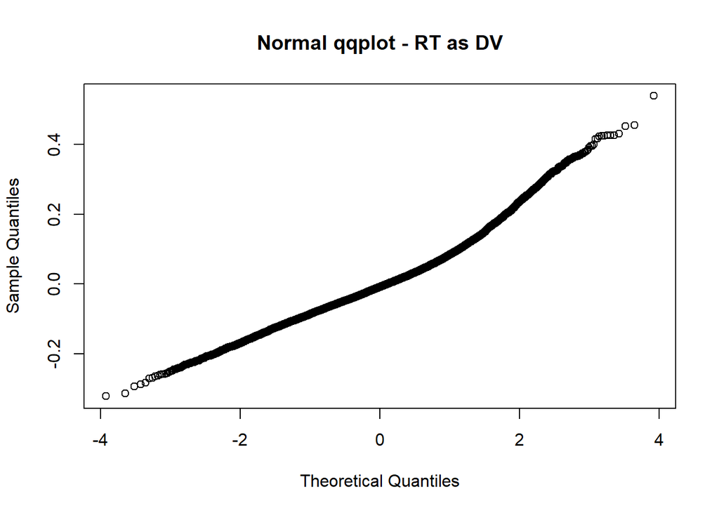

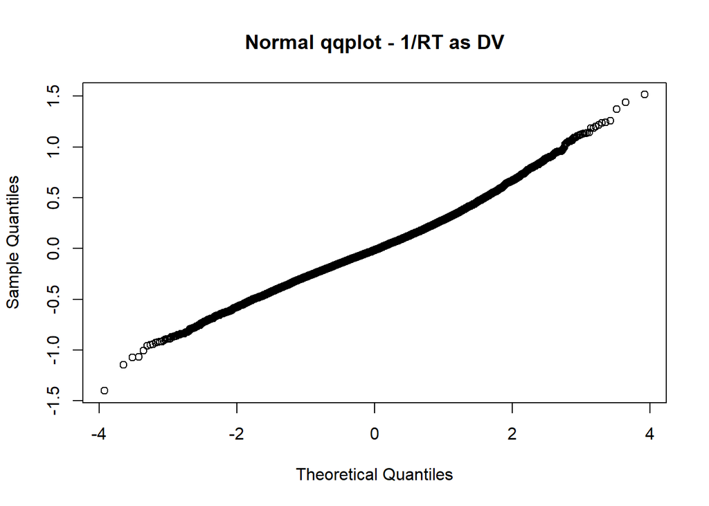

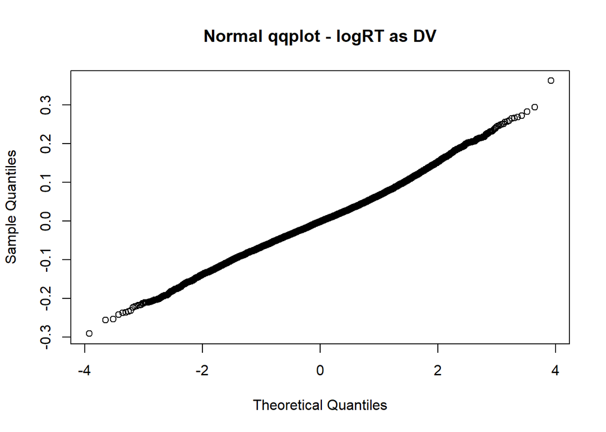

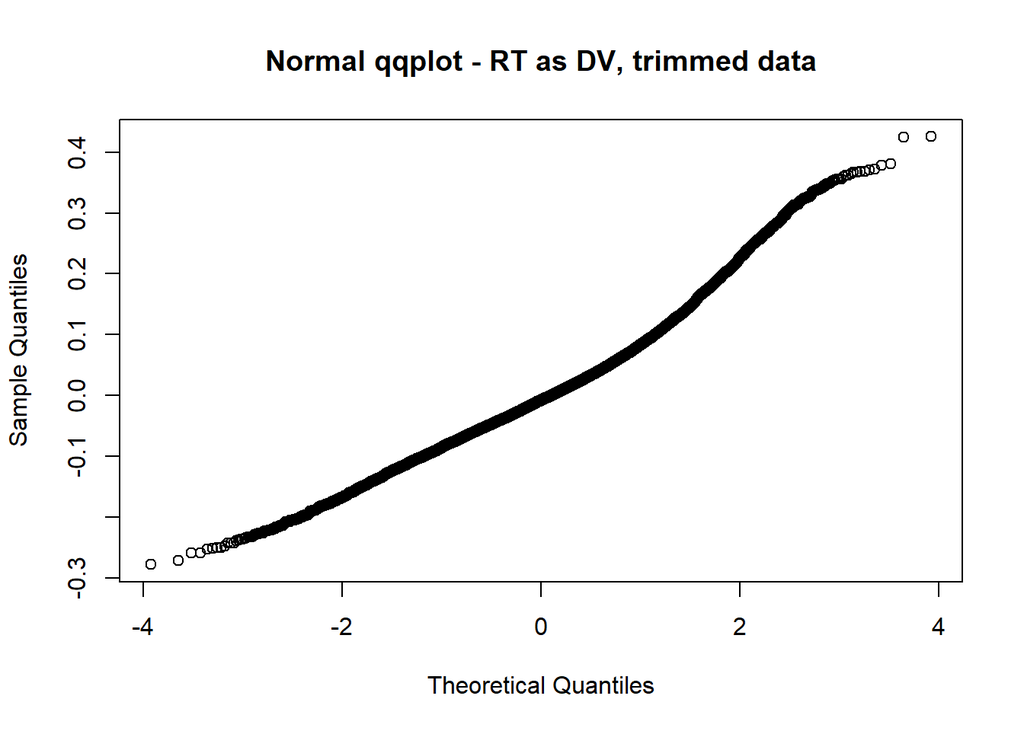

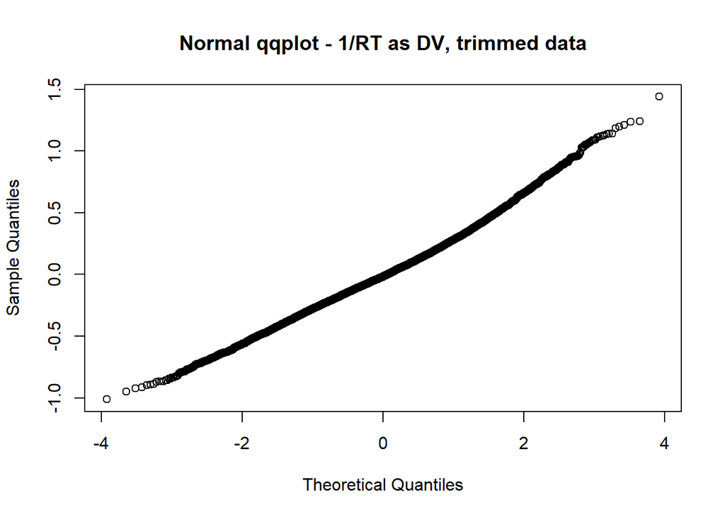

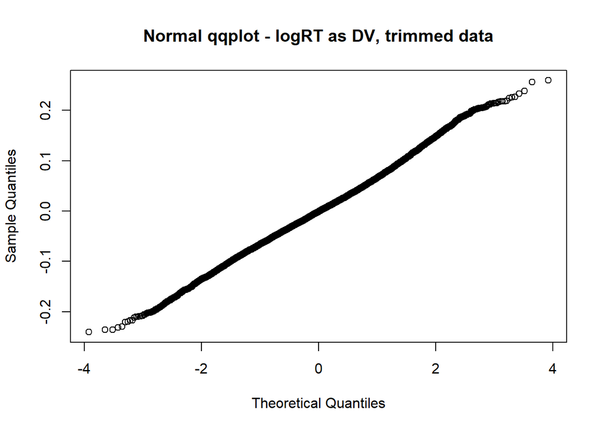

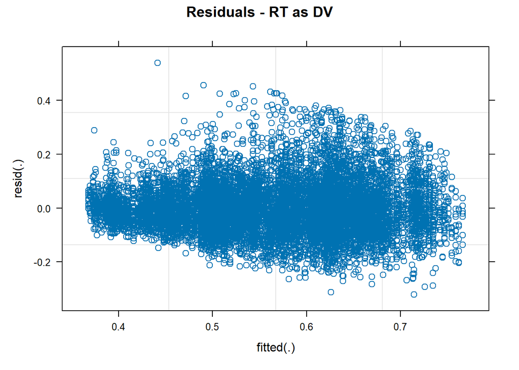

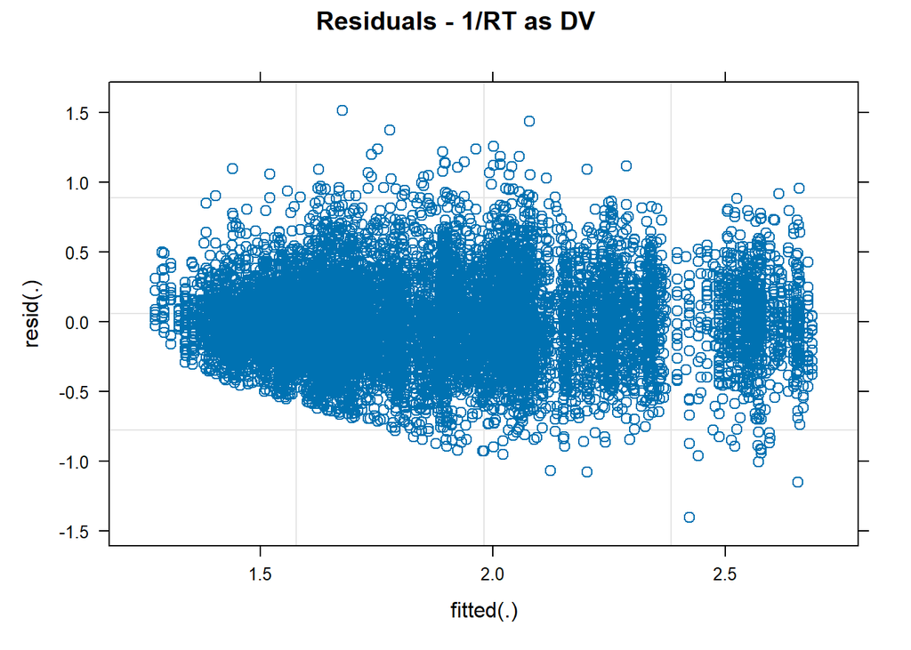

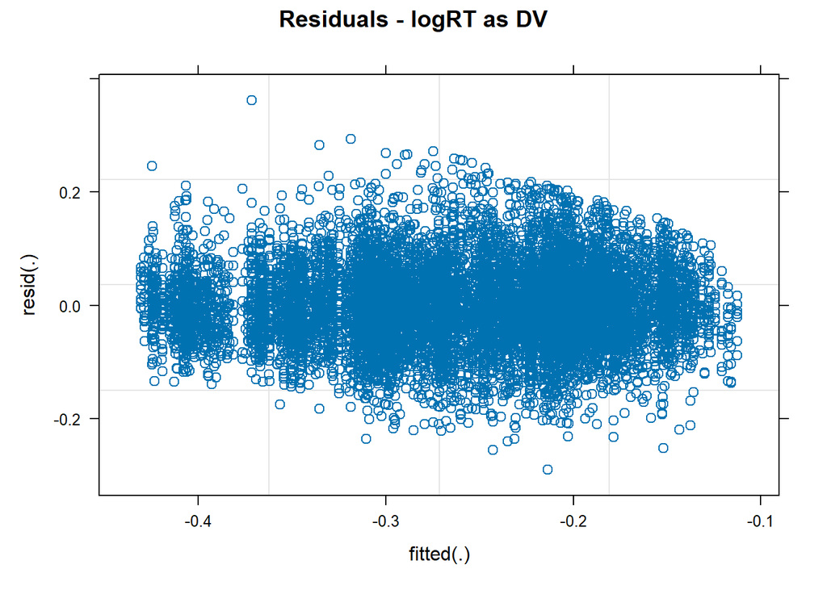

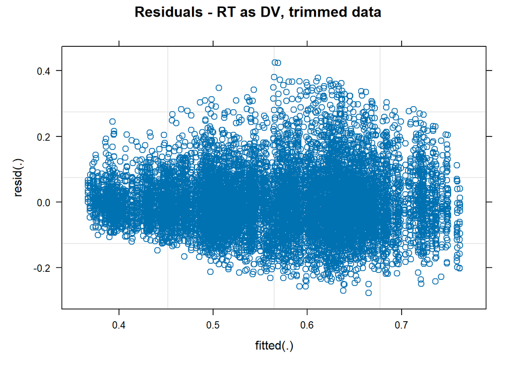

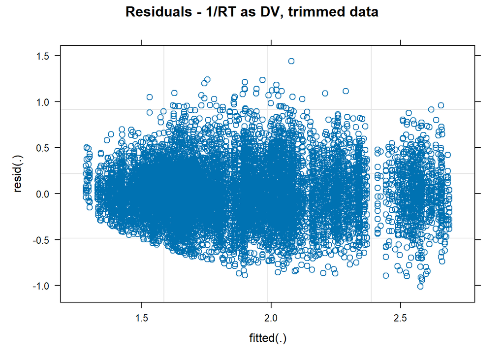

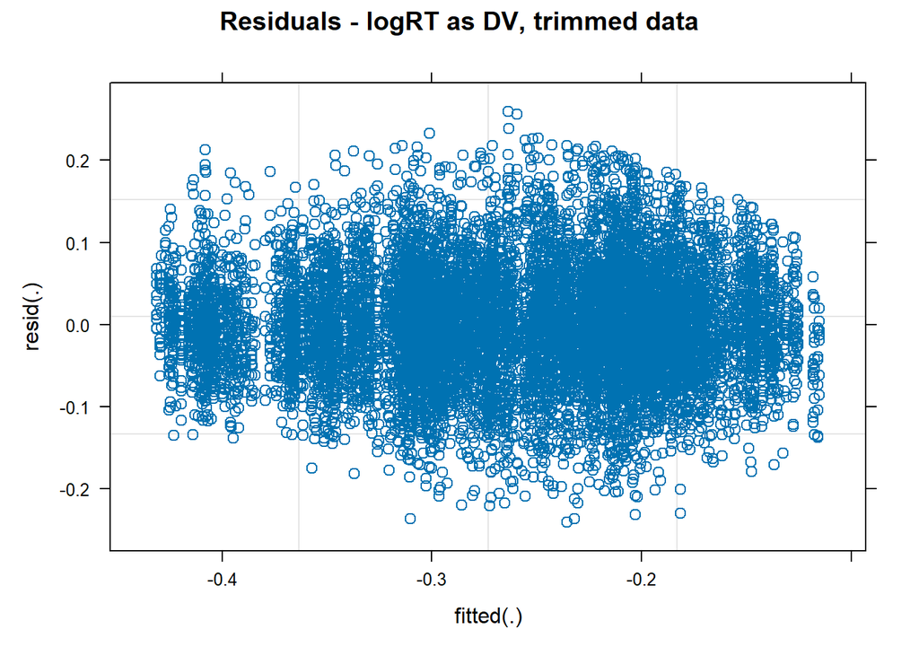

Não parece haver correlação importante entre os valores ajustados e os resíduos.

# 2. Encontrar máxima estrutura que convirja

Aqui, encontrar a estrutura máxima do modelo que convirja. Há uma série de algoritmos para isso, incluindo a heurística “keep it maximal” de Barr et al. (2013) e variações. Neste experimento, utilizamos o pacote buildmer (Voeten 2022), que automatiza esse processo. Em outro documento, comparamos o desempenho do buildmer com as heurísticas manuais e observamos que os resultados são qualitativamente idênticos.

```r
fplmm <- buildmer(formula = RT ~ scaledNumForeperiod*condition*oneBackFP +
                    (1+scaledNumForeperiod*condition*oneBackFP|ID),
                  data = data2,
                  buildmerControl = list(crit = "LRT",
                                         family = gaussian(link = "identity"),
                                         calc.anova = TRUE))
```

```
##    grouping                                    term
## 1      <NA>                                       1
## 3      <NA>                               condition
## 2      <NA>                     scaledNumForeperiod
## 4      <NA>           scaledNumForeperiod:condition
## 5      <NA>                               oneBackFP
## 6      <NA>           scaledNumForeperiod:oneBackFP
## 7      <NA>                     condition:oneBackFP
## 8      <NA> scaledNumForeperiod:condition:oneBackFP
## 9        ID                                       1
## 11       ID                               condition
## 10       ID                     scaledNumForeperiod
##                                            block        score Iteration
## 1                                        NA NA 1           NA         1
## 3                                NA NA condition  -22.0214157         1
```

[output cut: 63 more lines]

```r
formula(fplmm)
```

```
## RT ~ 1 + condition + scaledNumForeperiod + condition:scaledNumForeperiod +
##     oneBackFP + scaledNumForeperiod:oneBackFP + (1 + condition +
##     scaledNumForeperiod | ID)
```

# References

Barr, Dale J., Roger Levy, Christoph Scheepers, and Harry J. Tily. 2013. “Random Effects Structure for Confirmatory Hypothesis Testing: Keep It Maximal.” *Journal of Memory and Language* 68 (3): 255–78. https://doi.org/10.1016/j.jml.2012.11.001.

Voeten, Cesko C. 2022. *Buildmer: Stepwise Elimination and Term Reordering for Mixed-Effects Regression*. https://CRAN.R-project.org/package=buildmer.